# **Titanic Analysis**

Sathyam A

2023-10-05

# Titanic Survivors Analysis

In this analysis, we explore the Titanic data set to understand the factors that influenced the survival of passengers on the Titanic. We will use R and various data visualization techniques to gain insights into the data and draw meaningful conclusions

**Initial Steps followed**

```r
library(tidyverse)
```

```r
library(ggplot2)
```

- First we have installed the tidyverse package and load it with the library() function This is because we wanted to use the dplyr for mutating the data set
- Then we load the .csv file in df from our local system then we mutate the column

```r
df <- read.csv("C:\\Users\\Admin\\Desktop\\Excel Data Sets\\DataSets 2\\Titanic.csv")
View(df)

df <- df %>%
  mutate(survived = as.character(survived)) #Changing the data type of survived
```

## The Analysis and Visualization Part

**Survival Rate Overview:**

*The first bar chart shows the overall survival rates on a binary scale (0 for not survived, 1 for survived).

*It appears that more passengers did not survive (0) than those who survived (1), indicating a higher mortality rate

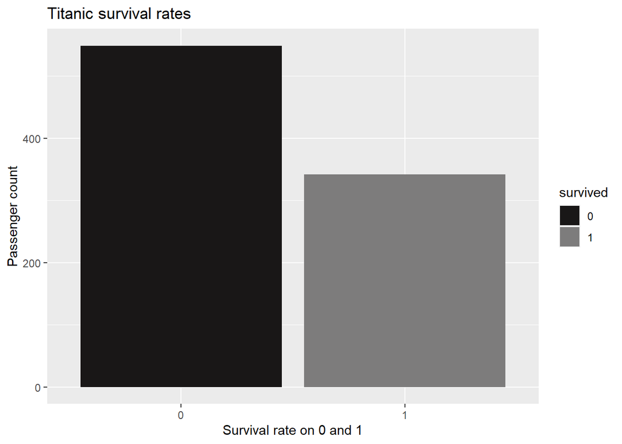

```r
ggplot(df , aes(x = survived , fill = survived))+
  scale_fill_manual(values = c("1" = "#7D7C7C" , "0" = "#191717")) +
  geom_bar() + labs(x = "Survival rate on 0 and 1",
                    y = "Passenger count",
                    title = "Titanic survival rates")
```

**Survival Rate by Gender:**

- The second bar chart illustrates the survival rates by gender (male and female).
- It’s clear that more females survived compared to males, suggesting that gender had a significant influence on survival.

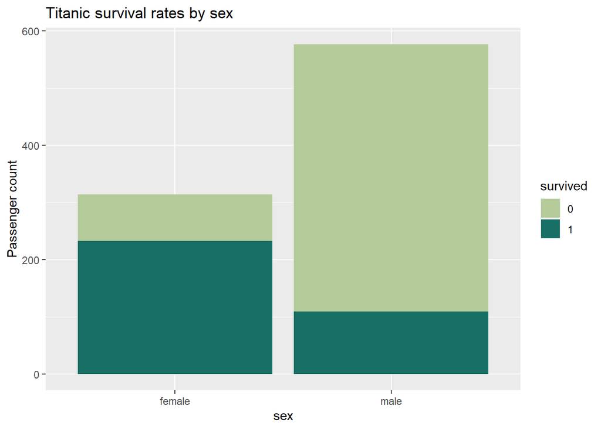

```r
ggplot(data = df) +geom_bar(mapping = aes(x = sex , fill = survived))+
  scale_fill_manual(values = c("1" = "#186F65" , "0" = "#B5CB99")) +
  labs(y = "Passenger count",
       title = "Titanic survival rates by sex")
```

**Survival Rate by Passenger Class:**

- The third bar chart presents the survival rates categorized by passenger class (1st, 2nd, and 3rd class).
- Passengers in the 1st class had a higher survival rate compared to those in the 2nd and 3rd classes.

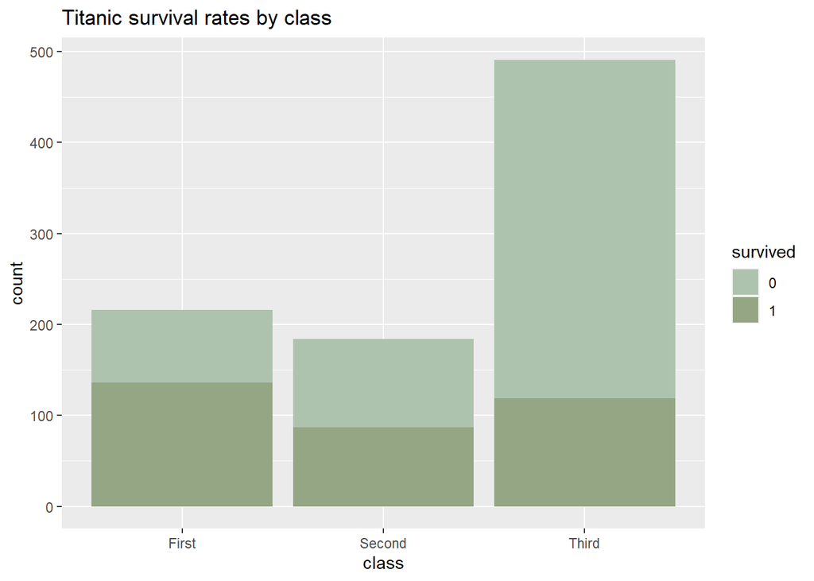

```r
ggplot(data = df) + geom_bar(mapping = aes(x = class , fill = survived))+
  scale_fill_manual(values = c("1" = "#94A684" , "0" = "#AEC3AE")) +
  labs(title = "Titanic survival rates by class")
```

**Age Distribution:**

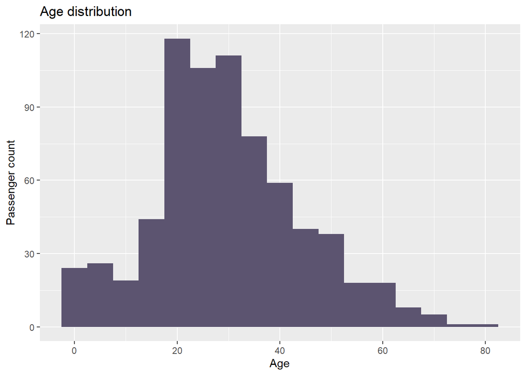

```r
ggplot(data = df) + geom_histogram(mapping = aes(x = age) , fill = "#5C5470", binwidth = 5)+
  labs(y = "Passenger count",
       x = "Age",
       title = "Age distribution")
```

**Survival Rates by Age, Class, and Sex:**

- The density plot with facets (subplots) shows the survival rates by age, class, and sex.
- It suggests that survival rates varied across age groups, with some peaks and variations.
- In general, it appears that females in the 1st and 2nd classes had higher survival rates across different age groups

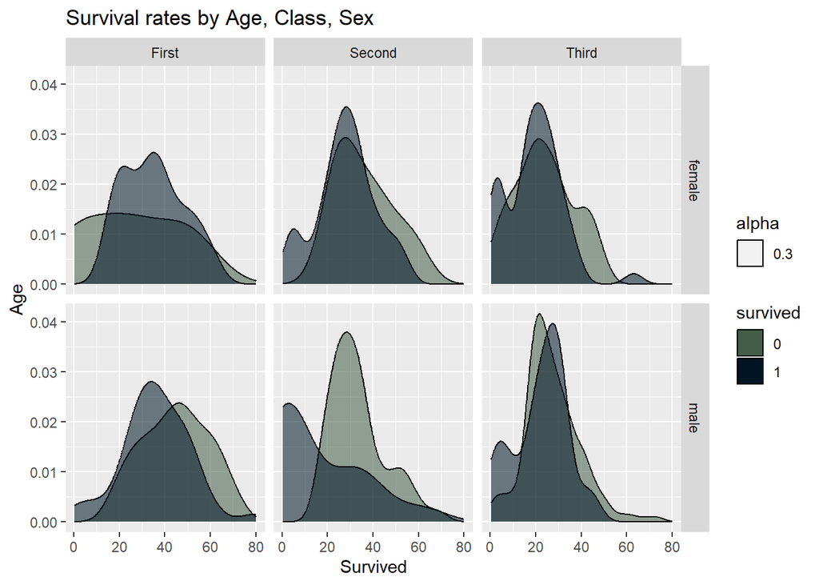

```r
ggplot(data = df) + geom_density(mapping = aes(x = age , fill = survived , alpha = 0.3)) +
  facet_grid(sex~class) + scale_fill_manual(values = c("1" = "#001524" , "0" = "#445D48")) + labs(y = "Age",
                               x = "Survived",
                               title = "Survival rates by Age, Class, Sex")
```

**Survival Rates by Age:**

- The box plot illustrates the distribution of ages for both survivors and non-survivors.

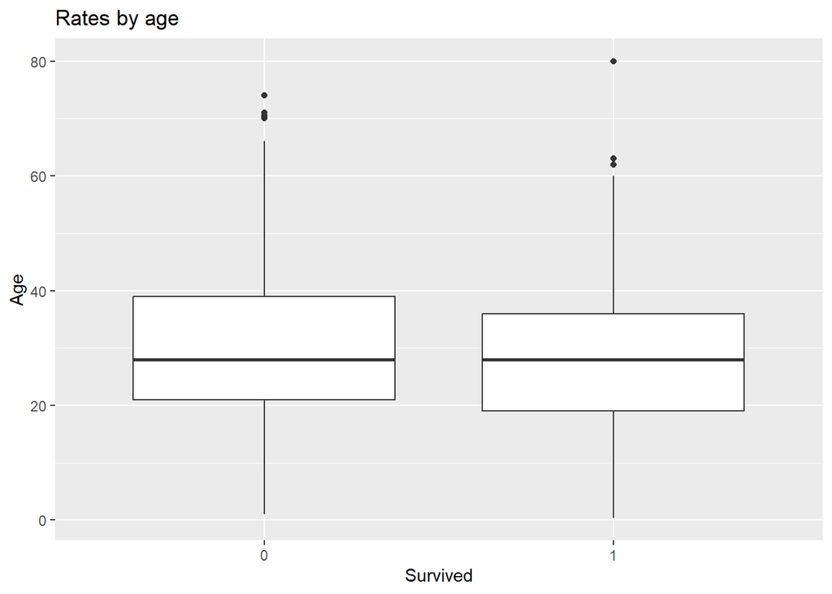

```r
ggplot(data = df) + geom_boxplot(mapping = aes(x = survived , y = age)) +
  labs(y = "Age",
       x = "Survived",
       title = "Rates by age")
```

**Survival rates by Embarkation point , Class and Sex**

- This a bar plot depicting the survival rates of Titanic passengers. The data is grouped by the embarkation point, passenger class, and sex.

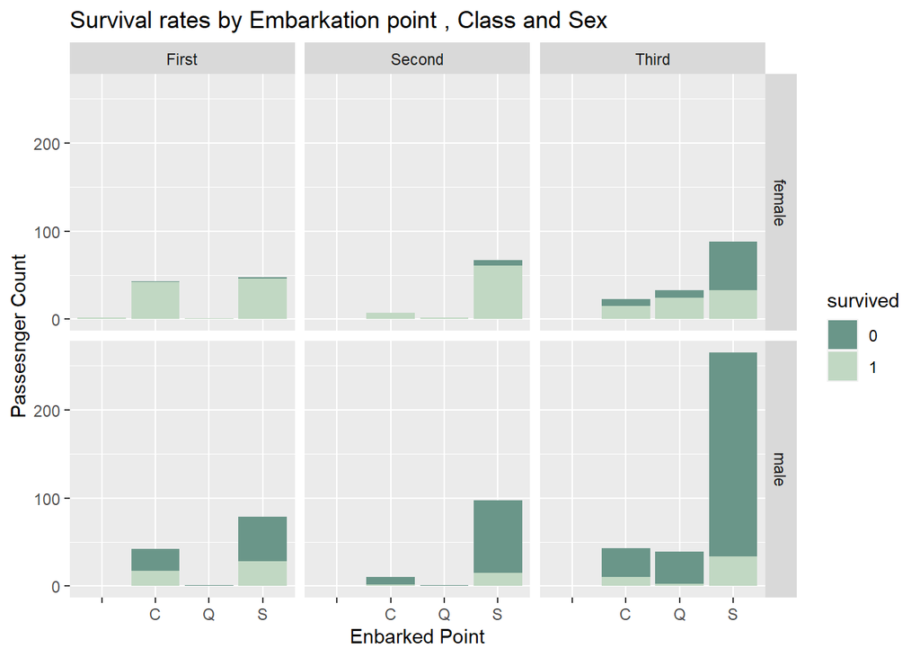

```r
ggplot(data= df) + geom_bar(mapping = aes(x = embarked , fill = survived)) +
  scale_fill_manual(values = c("1" = "#C1D8C3" , "0" = "#6A9689")) +
  facet_grid(sex~class) + labs(x = "Enbarked Point" , y = "Passesnger Count" , title = "Survival rates by Embarkation point , Class and Sex")
```

**Survival rates by Alone Status and Gender** * This bar graph plot tell the survival rates of the people who were alone and who had come with their family , friends or any known person

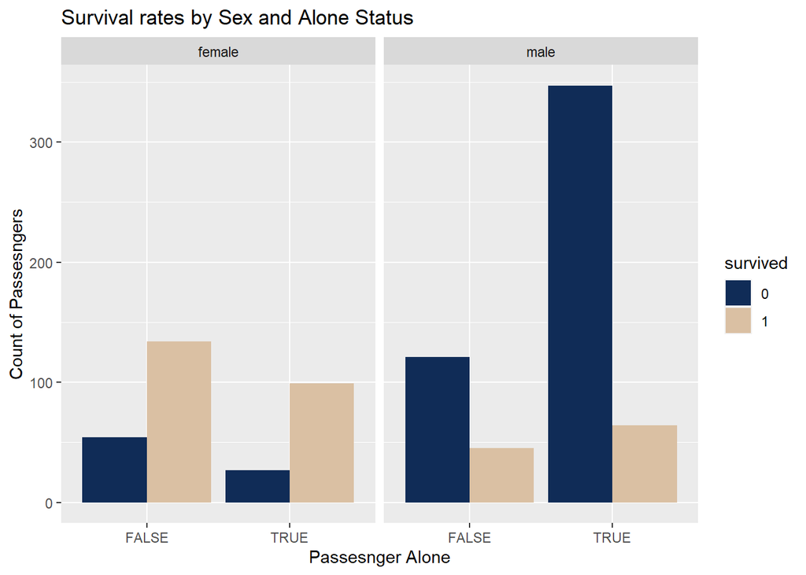

```r
ggplot(data = df) + geom_bar(mapping = aes(x = alone , fill = survived) , position = "dodge") +
  facet_wrap(~sex) + scale_fill_manual(values = c("1" = "#DAC0A3" , "0" = "#102C57")) +
  labs(y = "Count of Passesngers" , x = "Passesnger Alone" , title = "Survival rates by Sex and Alone Status")
```

## Some key Insights

- Among Male and Female, Female had higher surviving rate.
- 61% people died whereas 38% has survived in titanic disaster.
- Third class passengers has died the most among the other two class passengers.
- Male third class passengers had more death rate than among all the genders and class.
- Highest survival rate is among female first class passengers.
- Maximum number of men and women have lost their lives who had embarked from Southampton and those were from the third class
- Men passengers who traveled alone had lost the lives more